# Assignment 9

Jacob Wallin

2025-11-17

## Setup

```r
knitr::opts_chunk$set(
  echo = TRUE,
  message = FALSE,
  warning = FALSE
)

library(readr)
library(dplyr)
```

```r
library(ggplot2)
library(janitor)
library(broom)

if (!dir.exists("figs")) dir.create("figs")
```

## Load and inspect data

```r
admissions_raw <- read_csv("GradSchool_Admissions.csv")

admissions <- admissions_raw |>
  clean_names() |>
  mutate(
    admit = factor(admit, levels = c(0, 1),
                   labels = c("rejected", "admitted")),
    rank  = factor(rank,
                   levels = sort(unique(rank)),
                   labels = paste("Rank", sort(unique(rank))))
  )

glimpse(admissions)
```

```
## Rows: 400
## Columns: 4
## $ admit <fct> rejected, admitted, admitted, admitted, rejected, admitted, admi…
## $ gre   <dbl> 380, 660, 800, 640, 520, 760, 560, 400, 540, 700, 800, 440, 760,…
## $ gpa   <dbl> 3.61, 3.67, 4.00, 3.19, 2.93, 3.00, 2.98, 3.08, 3.39, 3.92, 4.00…
## $ rank  <fct> Rank 3, Rank 3, Rank 1, Rank 4, Rank 4, Rank 2, Rank 1, Rank 2, …
```

```r
summary(admissions)
```

```
##       admit          gre             gpa            rank
##  rejected:273   Min.   :220.0   Min.   :2.260   Rank 1: 61
##  admitted:127   1st Qu.:520.0   1st Qu.:3.130   Rank 2:151
##                 Median :580.0   Median :3.395   Rank 3:121
##                 Mean   :587.7   Mean   :3.390   Rank 4: 67
##                 3rd Qu.:660.0   3rd Qu.:3.670
##                 Max.   :800.0   Max.   :4.000
```

## Data analysis

```r
# Admission counts
admissions |>
  count(admit)
```

```
## # A tibble: 2 × 2
##   admit        n
##   <fct>    <int>
## 1 rejected   273
## 2 admitted   127
```

```r
# Admission proportion by rank
admissions |>
  count(rank, admit) |>
  group_by(rank) |>
  mutate(prop = n / sum(n))
```

```
## # A tibble: 8 × 4
## # Groups:   rank [4]
##   rank   admit        n  prop
##   <fct>  <fct>    <int> <dbl>
## 1 Rank 1 rejected    28 0.459
## 2 Rank 1 admitted    33 0.541
## 3 Rank 2 rejected    97 0.642
## 4 Rank 2 admitted    54 0.358
## 5 Rank 3 rejected    93 0.769
## 6 Rank 3 admitted    28 0.231
## 7 Rank 4 rejected    55 0.821
## 8 Rank 4 admitted    12 0.179
```

### Summaries

From the quick summary, most people in this dataset didn’t get in. Also, the school rank already looks like it might matter. The higher-ranked schools seem to have better acceptance numbers.

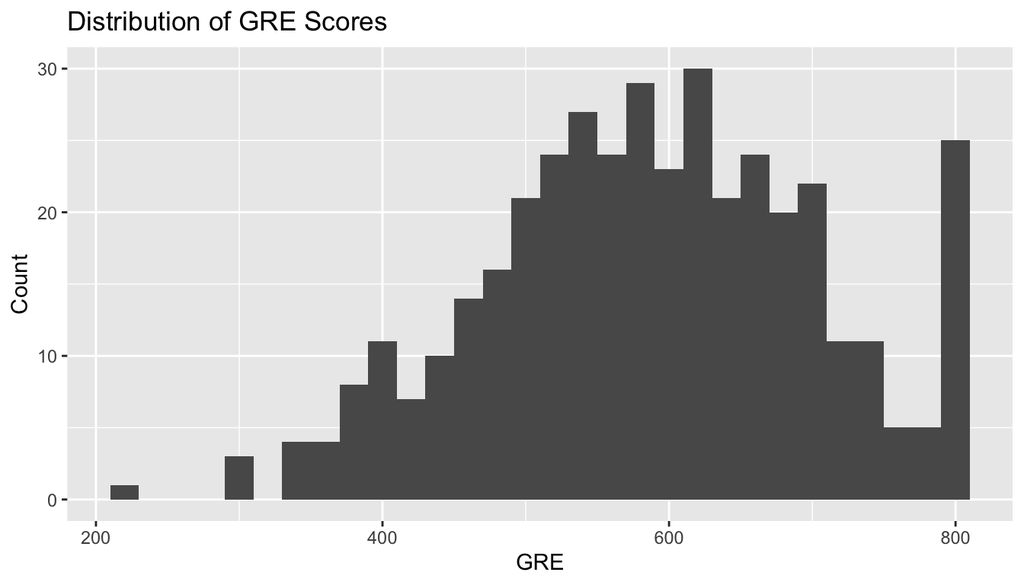

```r
# GRE distribution
ggplot(admissions, aes(x = gre)) +
  geom_histogram(bins = 30) +
  labs(title = "Distribution of GRE Scores",
       x = "GRE", y = "Count")
```

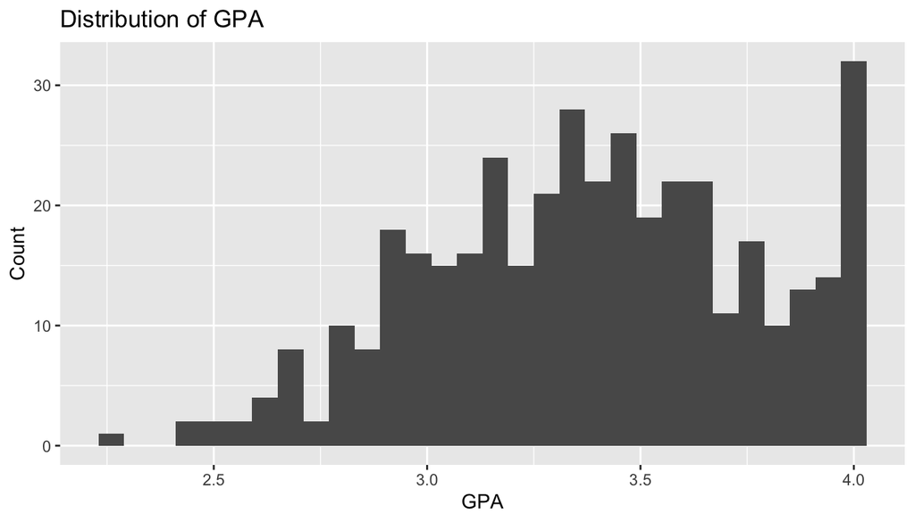

```r
# GPA distribution
ggplot(admissions, aes(x = gpa)) +
  geom_histogram(bins = 30) +
  labs(title = "Distribution of GPA",
       x = "GPA", y = "Count")
```

### Histograms

GRE scores have a wide range, but most people seem to land somewhere in the middle. There are a few really high and really low scores.

GPAs are mostly pretty high. Almost everyone is between a 3.0 and 4.0, so the dataset doesn’t really include many low-GPA applicants.

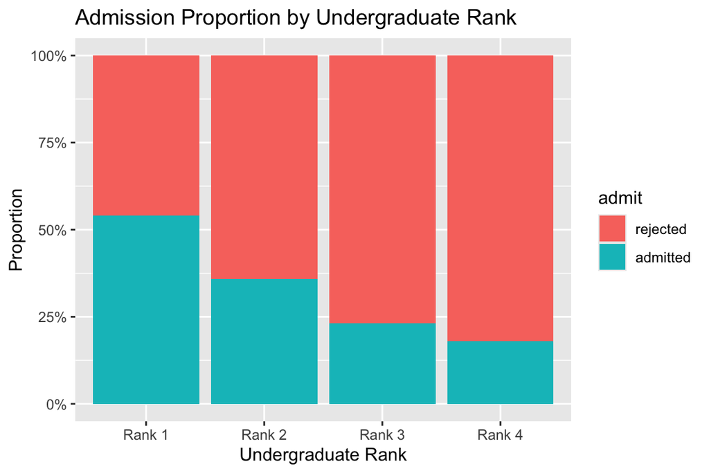

```r
ggplot(admissions, aes(x = rank, fill = admit)) +
  geom_bar(position = "fill") +
  scale_y_continuous(labels = scales::percent) +
  labs(title = "Admission Proportion by Undergraduate Rank",
       x = "Undergraduate Rank",
       y = "Proportion")
```

### Rank vs. Admit

This plot basically shows that the rank of your undergrad school definitely matters. People from Rank 1 and Rank 2 schools have way better chances than Rank 3 or Rank 4.

## Logistic regression modeling

```r
# Null model (intercept only)
m0 <- glm(admit ~ 1,
          data = admissions,
          family = binomial)

# Model 1: GRE + GPA
m1 <- glm(admit ~ gre + gpa,
          data = admissions,
          family = binomial)

# Model 2: GRE + GPA + rank
m2 <- glm(admit ~ gre + gpa + rank,
          data = admissions,
          family = binomial)

# Compare by AIC
AIC(m0, m1, m2)
```

```
##    df      AIC
## m0  1 501.9765
## m1  3 486.3440
## m2  6 470.5175
```

```r
# Likelihood ratio tests (model improvement)
anova(m0, m1, test = "Chisq")
```

```
## Analysis of Deviance Table
##
## Model 1: admit ~ 1
## Model 2: admit ~ gre + gpa
##   Resid. Df Resid. Dev Df Deviance  Pr(>Chi)
## 1       399     499.98
## 2       397     480.34  2   19.633 5.456e-05 ***
## ---
## Signif. codes:  0 '***' 0.001 '**' 0.01 '*' 0.05 '.' 0.1 ' ' 1
```

```r
anova(m1, m2, test = "Chisq")
```

```
## Analysis of Deviance Table
##
## Model 1: admit ~ gre + gpa
## Model 2: admit ~ gre + gpa + rank
##   Resid. Df Resid. Dev Df Deviance  Pr(>Chi)
## 1       397     480.34
## 2       394     458.52  3   21.826 7.088e-05 ***
## ---
## Signif. codes:  0 '***' 0.001 '**' 0.01 '*' 0.05 '.' 0.1 ' ' 1
```

```r
# Detailed output for best model
summary(m2)
```

```
##
## Call:
## glm(formula = admit ~ gre + gpa + rank, family = binomial, data = admissions)
##
## Coefficients:
##              Estimate Std. Error z value Pr(>|z|)
## (Intercept) -3.989979   1.139951  -3.500 0.000465 ***
## gre          0.002264   0.001094   2.070 0.038465 *
## gpa          0.804038   0.331819   2.423 0.015388 *
## rankRank 2  -0.675443   0.316490  -2.134 0.032829 *
## rankRank 3  -1.340204   0.345306  -3.881 0.000104 ***
## rankRank 4  -1.551464   0.417832  -3.713 0.000205 ***
## ---
## Signif. codes:  0 '***' 0.001 '**' 0.01 '*' 0.05 '.' 0.1 ' ' 1
##
## (Dispersion parameter for binomial family taken to be 1)
##
##     Null deviance: 499.98  on 399  degrees of freedom
## Residual deviance: 458.52  on 394  degrees of freedom
## AIC: 470.52
##
## Number of Fisher Scoring iterations: 4
```

### Model Selection Summary

I tested three different logistic regression models to see what actually predicts whether someone gets into grad school:

1. **Null model:** no predictors at all
2. **Model 1:** GRE + GPA
3. **Model 2:** GRE + GPA + Rank of undergrad school

First, comparing the null model to the GRE+GPA model, the improvement was super significant (χ² = 19.63, p < 0.001). Basically, GRE and GPA obviously help explain who gets admitted.

Then I compared that model to the one that also includes the rank of the undergrad program. That was also a big improvement (χ² = 21.83, p < 0.001), meaning the rank of the school you went to actually matters, even after controlling for your scores.

Since Model 2 had the lowest AIC and was the best-fitting overall, that’s the model I went with. So yeah — GRE, GPA, and school rank all play a role in admission chances.

## Predictions and model performance

```r
admissions_pred <- admissions |>
  mutate(
    p_hat = predict(m2, type = "response"),
    admit_pred = ifelse(p_hat >= 0.5, "admitted", "rejected"),
    admit_pred = factor(admit_pred, levels = levels(admit))
  )

conf_mat <- table(
  observed = admissions_pred$admit,
  predicted = admissions_pred$admit_pred
)

conf_mat
```

```
##           predicted
## observed   rejected admitted
##   rejected      254       19
##   admitted       97       30
```

```r
accuracy <- sum(diag(conf_mat)) / sum(conf_mat)
accuracy
```

```
## [1] 0.71
```

### Prediction Summary

Using the final model (GRE + GPA + Rank), I generated predicted probabilities and turned them into admitted/rejected calls using a 0.5 cutoff. The confusion matrix and accuracy value show that the model gets most of the cases right, but it still messes up a bit on borderline applicants. Honestly, that makes sense because admissions depend on a lot more than just GRE/GPA/stats.

## Conclusion

Overall, the analysis suggests that higher GRE scores, higher GPAs, and attending a higher-ranked undergrad school are all linked to better odds of grad school admission. Rank still matters even after controlling for GRE and GPA, which lines up with how competitive programs usually work. The model does a decent job predicting outcomes, but it’s not perfect, and real decisions probably also depend on other factors that aren’t in this dataset (like letters, personal statements, etc.).